# HW6_Spotify_Songs

In this assignment, you will be working with a dataset of songs played on Spotify in 2020, and you’ll be writing code to explore the range of danceability scores in the data, using standard deviation and histograms. You’ll also write up your findings.

### Task 1: Load the tidyverse

```r
library(tidyverse)
```

### Task 2: Load the Spotify Songs dataset from https://raw.githubusercontent.com/dwillis/jour405/refs/heads/main/data/spotify_2020.csv

```r
spotify_songs <- read_csv("https://raw.githubusercontent.com/dwillis/jour405/refs/heads/main/data/spotify_2020.csv")
```

### Task 3: Calculate the mean and standard deviation of the danceability scores

Write code to calculate the mean and standard deviation of the danceability scores in the Spotify dataset. Display those.

```r
spotify_songs |>
  summarise(mean_dancaebility = mean(danceability), sd_danceability = sd(danceability))
```

```
## # A tibble: 1 × 2
##   mean_dancaebility sd_danceability
##               <dbl>           <dbl>
## 1             0.673           0.162
```

### Task 4: Create a histogram of the danceability scores

Write code to create a histogram of the danceability scores in the Spotify dataset, based on the example we did in class.

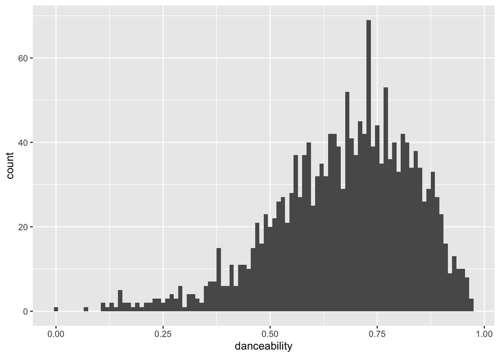

```r
spotify_songs |>
  ggplot() +
 geom_histogram(aes(x = danceability),  binwidth = .010)
```

### Task 5: Add a line to the histogram for the mean danceability score

Take the same code and add a vertical line to the histogram for the mean danceability score, based on the example in class.

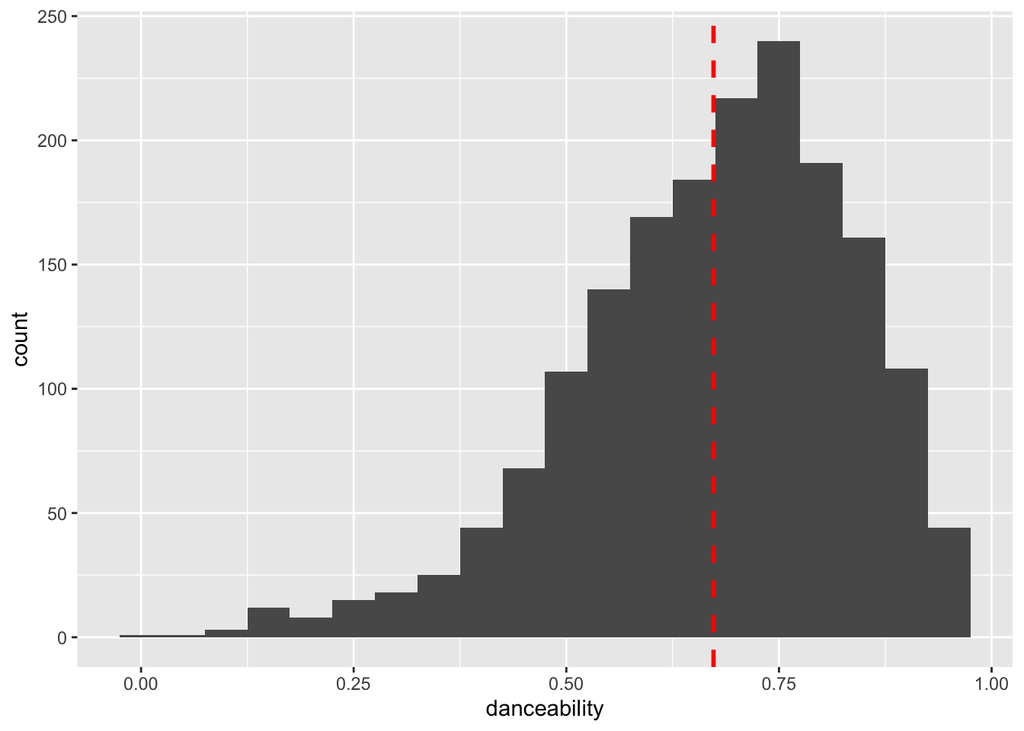

```r
spotify_songs |>
  ggplot() +
  geom_histogram(aes(x = danceability),  binwidth = .05) +
  geom_vline(aes(xintercept = mean(danceability)), color = 'red', linetype = "dashed", size = 1)
```

### Task 6: Add two lines to the histogram to show one standard deviation

Take the previous code and add two lines to the histogram for the 1st standard deviation below and above the mean score.

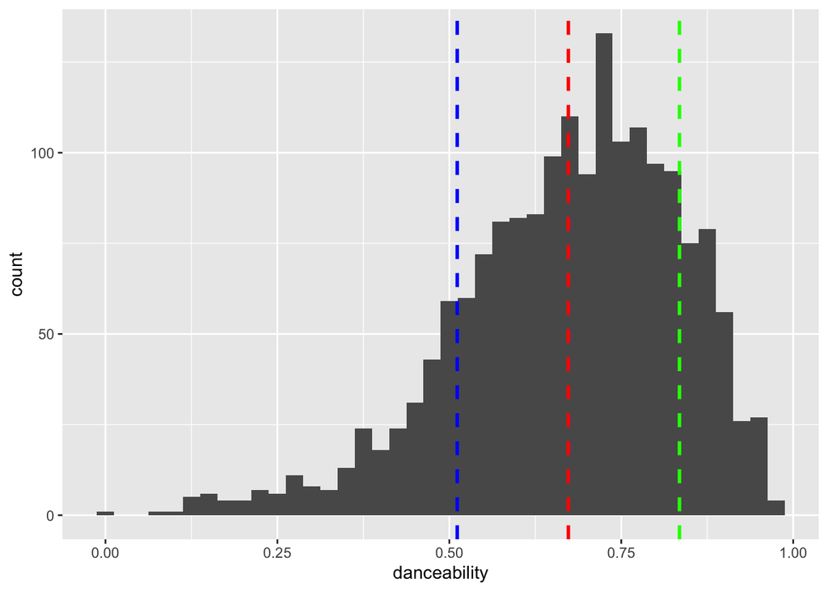

```r
spotify_songs |>
  ggplot() +
  geom_histogram(aes(x = danceability),  binwidth = .025) +
  geom_vline(aes(xintercept = mean(danceability)), color = 'red', linetype = "dashed", size = 1)  +
   geom_vline(aes(xintercept = mean(danceability) - sd(danceability)), color = 'blue', linetype = "dashed", size = 1) +
   geom_vline(aes(xintercept = mean(danceability) + sd(danceability)), color = 'green', linetype = "dashed", size = 1)
```

[output not shown]